# hw5

Author

Jessica Villanueva

```r
library(tidyverse)
w <- readRDS("/Users/Jessica/Downloads/STAT_128/HW5_Interpolation/sep2023.rds")
```

#### 1. Which data points are missing?

Hint: The data is missing in more than 1 place.

```r
# range of entire data set
range(w$time)
```

```
[1] "2023-09-14 20:45:00 UTC" "2023-09-28 19:45:00 UTC"
```

```r
# finding the days that have missing data
w |>
  group_by(day(time)) |>
  summarize(n())
```

```
# A tibble: 15 × 2
   `day(time)` `n()`
         <int> <int>
 1          14    13
 2          15    96
 3          16    96
 4          17    96
 5          18    96
 6          19    73
 7          20    17
 8          21    92
 9          22    96
10          23    96
11          24    96
12          25    96
13          26    96
14          27    96
15          28    80
```

```r
# finding the times that are missing
allTimes <- seq(from = min(w$time), to = max(w$time), by = "15 min")
missingTimes <- as.POSIXct(setdiff(allTimes, w$time), tz = "UTC")

# range of missing data points
range(missingTimes)
```

```
[1] "2023-09-19 17:30:00 UTC" "2023-09-21 11:00:00 UTC"
```

```r
# sanity check
table <- tibble(missingTimes)
table |>
  group_by(day(missingTimes)) |>
  summarize(n())
```

```
# A tibble: 3 × 2
  `day(missingTimes)` `n()`
                <int> <int>
1                  19    23
2                  20    79
3                  21     4
```

```r
missing <- tibble(time = missingTimes)
```

#### 2. Estimate the missing data, and provide a complete mathematical description of the fitted model you used.

```r
w2 <- filter(w, day(time) > 17 & day(time) < 22)
mul <- 2*pi/24

model <- lm(temperature ~ sin(mul * (hour(time) + minute(time)/60)), w2)
w2_pred <- bind_rows(w2, missing)
w2_pred$temperature <- predict(model, w2_pred)

coef(model)
```

```
                              (Intercept)
                                66.177737
sin(mul * (hour(time) + minute(time)/60))
                                -2.400571
```

$$y = \beta_0 + \beta_1 \sin(p * (h + m/60))$$

In this equation, $y$ is the temperature in Fahrenheit and is also the variable that we’re estimating. The variables $h$ and $m$ are being used to represent the hour, where $m$ is the fraction of the hour and represents minutes. The variable $p$ is being used to alter the wavelength of the sine wave to represent a 24 hour period, where $p = \frac{2\pi}{24}$. With the fitted values, the equation becomes:

$$y = 66.18 + -2.40\sin(p * (h+m/60))$$

#### 3. Plot the data, the estimates, and the fitted model.

Make it visually clear in the plot which are actual data points and which are estimates.

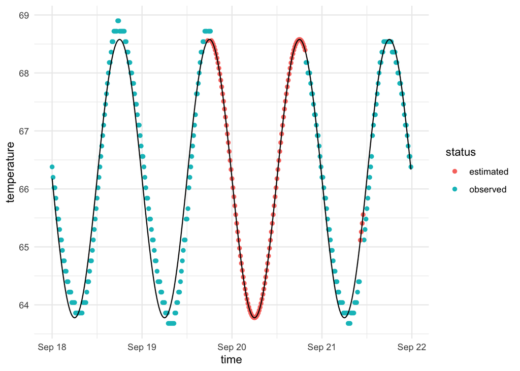

```r
missing$status <- "estimated"
w2$status <- "observed"
model <- lm(temperature ~ sin(mul * (hour(time) + minute(time)/60)), w2)
missing$temperature <- predict(model, missing)
w2 <- bind_rows(w2, missing)

ggplot(w2, aes(x = time, y = temperature)) +
  geom_point(aes(color = status)) +
  theme_minimal() +
  geom_line(data = w2_pred)
```

#### 4. How well did the estimates work?

Download the [complete data](https://waterdata.usgs.gov/monitoring-location/11446980/#parameterCode=00010&period=P7D&showMedian=true) from USGS or from the previous homework, and compare the estimates with the actual data points.

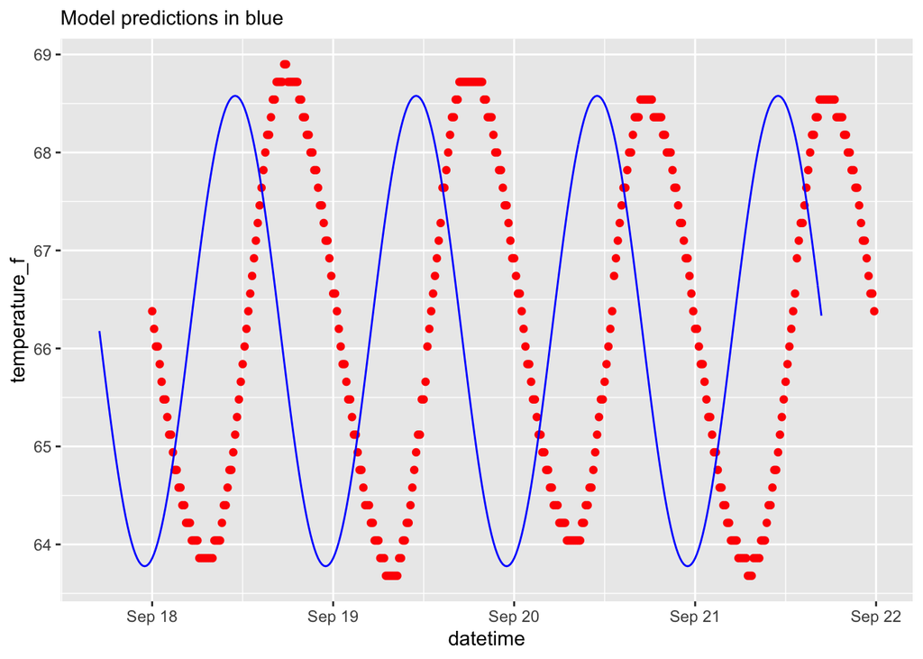

```r
water <- read_delim("/Users/Jessica/Downloads/STAT_128/HW4_DataSets/water-temp.txt",
                    comment="#", delim="\t") |>
  slice(-1) |>
  filter(day(datetime) > 17 & day(datetime) < 22 &
           year(datetime) == 2023 & month(datetime) == 9) |>
  rename(temperature = `15722_00010`, qual = `15722_00010_cd`) |>
  select(datetime, temperature, qual) |>
  mutate(temperature = as.double(temperature),
         datetime = ymd_hm(datetime, tz = "US/Pacific"),
         temperature_f = (temperature * 9)/5 + 32)
ggplot(water, aes(x = datetime, y = temperature_f)) +
  geom_point(color = "red") +
  geom_line(data = w2_pred, aes(x = time, y = temperature), color = "blue") +
  labs(subtitle = "Model predictions in blue")
```

I’m not entirely sure why the complete data is shifted compared to the data given in this homework. I checked the tibbles for each data frame and they start at the same date (and have the same number of observations) so I’m not sure why they’re started and ending on different x-values in the plot. But if we imagine that they are in the right place, we can see that the fitted model did a reasonable job predicting the actual values of the data set. It’s not exact because the model predicts the temperature will be the same every day at the same time. But, reality often deviates from what is expected in an experiment.